## Are the assumptions of this test reasonably met? If you have not had Stat 1, simply create a histogram of the agility scores for both groups (LM and LF) and given what you know about the CLT, comment on if you believe the sampling distribution of sample means (of your sample size) will be reasonably normal. In addition, does there look like there is significant visual evidence to suggest the standard deviations are different? ….. If you have had Stat 1, create the plots listed above (and any other plots you might prefer) and be prepared to be a teacher and teach what you know about the assumptions of the t-test and if those are assumption are reasonably met here.

```r
hello <- read.csv("FIFA Players.csv")
head(hello)
```

```
##   X     ID              Name Age                                          Photo
## 1 0 158023          L. Messi  31 https://cdn.sofifa.org/players/4/19/158023.png
## 2 1  20801 Cristiano Ronaldo  33  https://cdn.sofifa.org/players/4/19/20801.png
## 3 2 190871         Neymar Jr  26 https://cdn.sofifa.org/players/4/19/190871.png
## 4 3 193080            De Gea  27 https://cdn.sofifa.org/players/4/19/193080.png
## 5 4 192985      K. De Bruyne  27 https://cdn.sofifa.org/players/4/19/192985.png
## 6 5 183277         E. Hazard  27 https://cdn.sofifa.org/players/4/19/183277.png
##   Nationality                                Flag Overall Potential
## 1   Argentina https://cdn.sofifa.org/flags/52.png      94        94
## 2    Portugal https://cdn.sofifa.org/flags/38.png      94        94
## 3      Brazil https://cdn.sofifa.org/flags/54.png      92        93
## 4       Spain https://cdn.sofifa.org/flags/45.png      91        93
## 5     Belgium  https://cdn.sofifa.org/flags/7.png      91        92
## 6     Belgium  https://cdn.sofifa.org/flags/7.png      91        91
##                  Club                                    Club.Logo   Value
```

[output cut: 76 more lines]

```r
forwards <- subset(hello, hello$Position == "LF")
head(forwards)
```

```
##         X     ID           Name Age
## 6       5 183277      E. Hazard  27
## 16     15 211110      P. Dybala  24
## 77     76     41        Iniesta  34
## 273   272 198164 Jonathan Viera  28
## 1380 1379 190577      S. Blanco  30
## 1450 1449 204713    J. Campbell  26
##                                               Photo Nationality
## 6    https://cdn.sofifa.org/players/4/19/183277.png     Belgium
## 16   https://cdn.sofifa.org/players/4/19/211110.png   Argentina
## 77       https://cdn.sofifa.org/players/4/19/41.png       Spain
## 273  https://cdn.sofifa.org/players/4/19/198164.png       Spain
## 1380 https://cdn.sofifa.org/players/4/19/190577.png   Argentina
## 1450 https://cdn.sofifa.org/players/4/19/204713.png  Costa Rica
##                                     Flag Overall Potential
```

[output cut: 83 more lines]

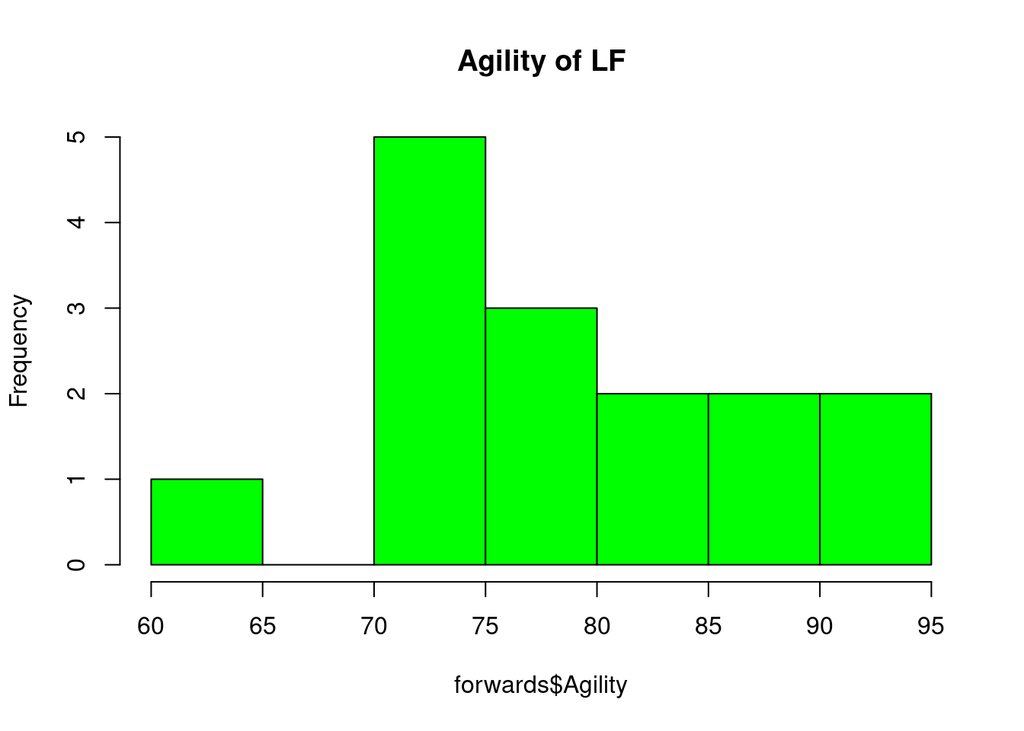

```r
hist(forwards$Agility, main = "Agility of LF", col="green")
```

```r
sd(forwards$Agility)
```

```
## [1] 8.310636
```

```r
LM <- subset(hello, hello$Position == "LM")
head(LM)
```

```
##     X     ID          Name Age                                          Photo
## 34 33 188567 P. Aubameyang  29 https://cdn.sofifa.org/players/4/19/188567.png
## 59 58 208722       S. Mané  26 https://cdn.sofifa.org/players/4/19/208722.png
## 66 65 190483 Douglas Costa  27 https://cdn.sofifa.org/players/4/19/190483.png
## 69 68 188350       M. Reus  29 https://cdn.sofifa.org/players/4/19/188350.png
## 87 86 193747          Koke  26 https://cdn.sofifa.org/players/4/19/193747.png
## 95 94 184267    Y. Brahimi  28 https://cdn.sofifa.org/players/4/19/184267.png
##    Nationality                                 Flag Overall Potential
## 34       Gabon https://cdn.sofifa.org/flags/115.png      88        88
## 59     Senegal https://cdn.sofifa.org/flags/136.png      86        87
## 66      Brazil  https://cdn.sofifa.org/flags/54.png      86        86
## 69     Germany  https://cdn.sofifa.org/flags/21.png      86        86
## 87       Spain  https://cdn.sofifa.org/flags/45.png      85        86
## 95     Algeria  https://cdn.sofifa.org/flags/97.png      85        85
##                 Club                                    Club.Logo  Value  Wage
```

[output cut: 76 more lines]

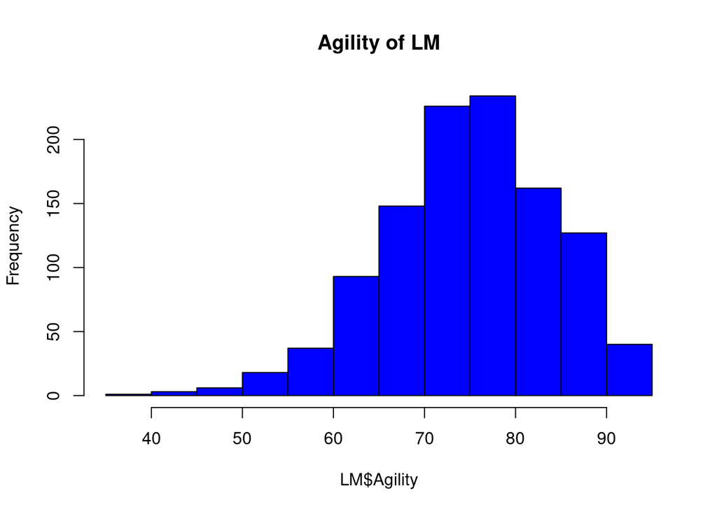

```r
hist(LM$Agility, main = "Agility of LM", col="blue")
```

```r
sd(LM$Agility)
```

```
## [1] 9.262842
```

#Part 2: (Estimated / expected time 3-5 hours and at least 3+ slides) #Select/create at least 2 categorical variables and select two continuous variables and perform an EDA. Also, at least one of the categorical variables should be created from a continuous variable (using the cut() function).

#Use these variables to explore the data and tell a story of what you discovered similar to what was shown in the asynch videos. You do not need to go so far as to use linear regression, but let your curiosity guide you along the way and feel free to use methods you are familiar with that are appropriate to answering those questions. Your evidence could be purely visual or could include additional methods, it is up to you… just do your best and have fun!

```r
library(formattable)
hello = read.csv("FIFA Players.csv")
hello1 = hello %>% select(Wage)
mean(hello1)
```

```
## [1] NA
```

```r
print('error due to non-numeric value')
```

```
## [1] "error due to non-numeric value"
```

```r
print('How to calculate mean in currency data in r')
```

```
## [1] "How to calculate mean in currency data in r"
```

```r
hello$Wage <- gsub("\\K","",hello$Wage)
hello$Wage <- gsub("\\€","",hello$Wage)
head(hello$Wage)
```

```
## [1] "565" "405" "290" "260" "355" "340"
```

```r
hello$Wage <- as.numeric(hello$Wage)
mean(hello$Wage)
```

```
## [1] 9.731312
```

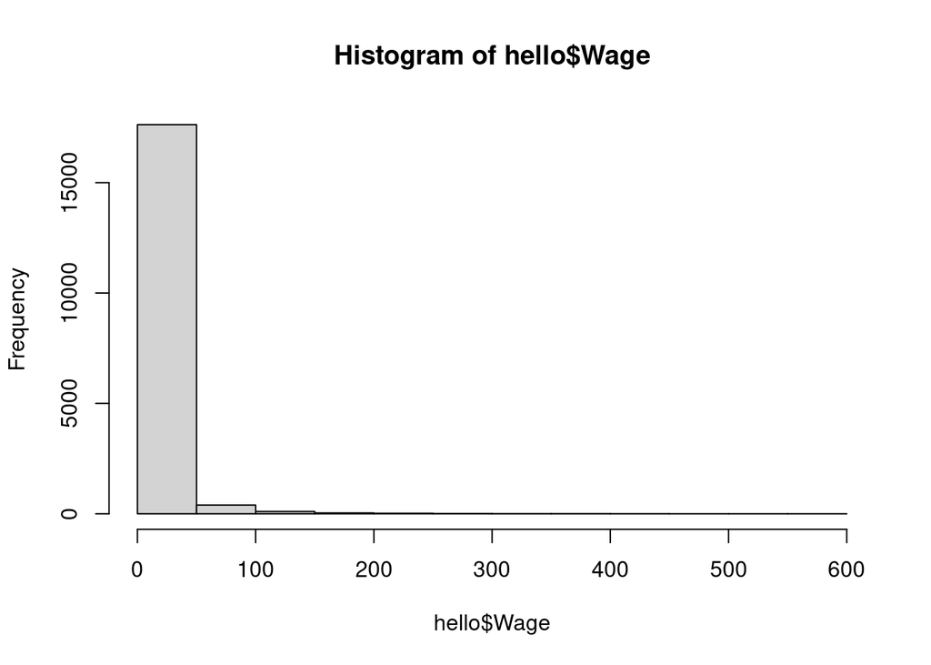

```r
hist(hello$Wage)
```

```r
head(hello)
```

```
##   X     ID              Name Age                                          Photo
## 1 0 158023          L. Messi  31 https://cdn.sofifa.org/players/4/19/158023.png
## 2 1  20801 Cristiano Ronaldo  33  https://cdn.sofifa.org/players/4/19/20801.png
## 3 2 190871         Neymar Jr  26 https://cdn.sofifa.org/players/4/19/190871.png
## 4 3 193080            De Gea  27 https://cdn.sofifa.org/players/4/19/193080.png
## 5 4 192985      K. De Bruyne  27 https://cdn.sofifa.org/players/4/19/192985.png
## 6 5 183277         E. Hazard  27 https://cdn.sofifa.org/players/4/19/183277.png
##   Nationality                                Flag Overall Potential
## 1   Argentina https://cdn.sofifa.org/flags/52.png      94        94
## 2    Portugal https://cdn.sofifa.org/flags/38.png      94        94
## 3      Brazil https://cdn.sofifa.org/flags/54.png      92        93
## 4       Spain https://cdn.sofifa.org/flags/45.png      91        93
## 5     Belgium  https://cdn.sofifa.org/flags/7.png      91        92
## 6     Belgium  https://cdn.sofifa.org/flags/7.png      91        91
##                  Club                                    Club.Logo   Value Wage
```

[output cut: 76 more lines]

```r
print('Wage vs position?')
```

```
## [1] "Wage vs position?"
```

```r
hello1 <- hello %>% group_by(Position) %>% summarize(meanWage = mean(Wage), count = n()) %>% arrange(meanWage)
print(hello1)
```

```
## # A tibble: 28 × 3
##    Position meanWage count
##    <chr>       <dbl> <int>
##  1 ""           1.35    60
##  2 "GK"         6.80  2025
##  3 "CB"         7.70  1778
##  4 "CM"         8.34  1394
##  5 "RWB"        8.60    87
##  6 "RB"         8.60  1291
##  7 "LB"         8.73  1322
##  8 "LWB"        9.08    78
##  9 "CDM"        9.32   948
## 10 "RM"         9.54  1124
## # … with 18 more rows
```

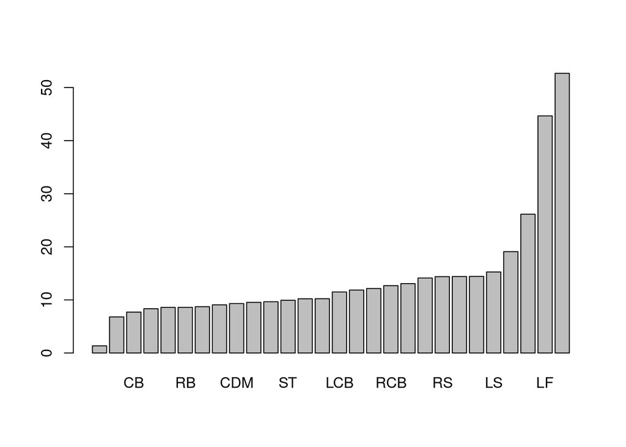

```r
barplot(hello1$meanWage, names.arg = hello1$Position)
```

#Part 3: Takeaways and Question for Live Session (≤𝟏 𝒉𝒐𝒖𝒓)

#What were your 3-5 (or more) key takeaways from this unit? #Were there any questions you had or topics that were fuzzy? (There is no minimum here. However, if you don’t have any questions, please simply state, “I didn’t have any questions, everything was pretty clear!” (or something to that effect.)

```r
print('I have a question for the purpose of the hypothizing mean value in T-Test. Is that getting general idea of mean value using givien data?')
```

```
## [1] "I have a question for the purpose of the hypothizing mean value in T-Test. Is that getting general idea of mean value using givien data?"
```

```r
print("centeral limit theorem is the theroretical backup for random sampling? is there any exception with it?")
```

```
## [1] "centeral limit theorem is the theroretical backup for random sampling? is there any exception with it?"
```

```r
print("most challenging part of this unit was df change from chr to num. is this all same as python or excel etc?")
```

```
## [1] "most challenging part of this unit was df change from chr to num. is this all same as python or excel etc?"
```